# Cord Blood → 2 Months: Does Infant Antibody Decay?

Scot Zens

2026-07-03

# The Question

Antigen-specific antibody in the newborn is generally **highest at birth** — almost all of it passively acquired across the placenta (reflected in cord blood) — and then **decays** over the first months of life with no infant production yet at 2 months (before primary immunisation). So the biological expectation for **CordBlood → InfMon2** is a **decrease** in nearly every feature.

An earlier version of this analysis found **positive median deltas** for many IgG subclass features — an apparent *increase* from cord to 2 months — which ran opposite to the biological expectation. That pattern was traced to a measurement artifact: the maternal and cord samples were assayed on **different bead-array plates, at different times**, from the infant 2-month samples, so the two timepoints were not on a common scale. Comparing them directly conflated true biological change with plate-to-plate and run-to-run differences in assay response.

To make the timepoints comparable, the cord/maternal (`mat_baa`) values were **normalized onto the infant assay scale** using per-(feature × antigen × plate × source) cross-calibration parameters derived from shared standard curves. This document reports the CordBlood → InfMon2 change **after that normalization**, and asks: with the cross-plate artifact removed, how many subjects increase versus decrease, feature by feature, and how much of the earlier apparent increase was artifactual rather than biological?

**Convention:** delta = log10 value at **InfMon2** − log10 value at **CordBlood**. Positive delta = an *increase*; negative delta = the *expected decay*.

# Data and Coverage

Features with at least one paired subject: **86**; with ≥ 10 paired: **39**.

Table 1. Per-feature coverage: subjects with CordBlood, with InfMon2, and with BOTH (the n used). Features with n paired = 0 were not measured at CordBlood and are excluded from all change analyses.

| Feature | n CordBlood | n InfMon2 | n paired (both) |
| --- | --- | --- | --- |
| DT_IgG | 287 | 287 | 262 |
| FHA_IgG | 287 | 287 | 262 |
| FIM_IgG | 287 | 287 | 262 |
| PRN_IgG | 287 | 287 | 262 |
| PT_IgG | 287 | 287 | 262 |
| TT_IgG | 287 | 287 | 262 |
| DT_IgG1 | 242 | 264 | 197 |
| DT_IgG4 | 242 | 264 | 197 |
| FHA_IgG1 | 242 | 264 | 197 |
| FHA_IgG4 | 242 | 264 | 197 |
| IPV1_IgG1 | 242 | 264 | 197 |
| IPV1_IgG4 | 242 | 264 | 197 |
| IPV2_IgG1 | 242 | 264 | 197 |
| IPV2_IgG4 | 242 | 264 | 197 |
| IPV3_IgG1 | 242 | 264 | 197 |
| IPV3_IgG4 | 242 | 264 | 197 |
| PRN_IgG1 | 242 | 264 | 197 |
| PRN_IgG4 | 242 | 264 | 197 |
| PT_IgG1 | 242 | 264 | 197 |
| PT_IgG4 | 242 | 264 | 197 |
| TT_IgG1 | 242 | 264 | 197 |
| TT_IgG4 | 242 | 264 | 197 |
| DT_IgG3 | 236 | 264 | 194 |
| FHA_IgG3 | 236 | 264 | 194 |
| IPV1_IgG3 | 236 | 264 | 194 |
| IPV2_IgG3 | 236 | 264 | 194 |
| IPV3_IgG3 | 236 | 264 | 194 |
| PRN_IgG3 | 236 | 264 | 194 |
| PT_IgG3 | 236 | 264 | 194 |
| TT_IgG3 | 236 | 264 | 194 |

[output cut: 56 more lines]

# Missing Data: Sources, Structure, and Implications

Not all subjects contribute equally to every feature’s paired analysis, and the reasons differ in important ways. Understanding the missing-data structure is essential before interpreting the change estimates: subjects who are missing at one or both visits may differ systematically from those with complete data, and the pattern of missingness itself reveals aspects of the assay design that affect what questions can be answered.

## Why paired counts differ across features

There are four distinct sources of missingness in this dataset, each with a different cause and a different implication for bias:

**Type A — Analyte never assayed at CordBlood (structural panel gap).** Effector function assays (ADCD, ADCP, ADNP), FcR-binding assays (FcgR2a, FcgR3b), B-memory (Bmem), FIM subclasses (IgG1–4), and total IgG for the IPV antigens were simply never run on CordBlood samples. These features have n<sub>CordBlood</sub> = 0. This is a design decision, not subject dropout, and it is **not correctable** from the existing data. No inference about CordBlood→InfMon2 change is possible for these analytes.

**Type B — CordBlood subclass panel run on a smaller sub-cohort than InfMon2.** For features that *do* have CordBlood data, the number of CordBlood observations is consistently smaller than InfMon2 for subclass assays (n<sub>cord</sub> < n<sub>inf</sub>), and the CordBlood counts step down in a structured way by analyte:

Table 2. Step-down in CordBlood sample size by analyte group. Each row represents a set of features sharing the same CordBlood n. The gap (InfMon2 minus CordBlood) quantifies subjects with InfMon2 data but no CordBlood measurement for that analyte group — subjects who cannot contribute to any paired change analysis for those features.

| Analyte group | N features | Typical n CordBlood | Typical n InfMon2 | Typical n paired | InfMon2 minus CordBlood |
| --- | --- | --- | --- | --- | --- |
| Total IgG (antigen-specific) | 6 | 287 | 287 | 262 | 0 |
| IgG1 and IgG4 | 16 | 242 | 264 | 197 | 22 |
| IgG3 | 8 | 236 | 264 | 194 | 28 |
| IgG2 — core antigens | 5 | 225 | 264 | 180 | 39 |
| WHOLE_WT_IgG | 1 | 209 | 223 | 194 | 14 |
| IgG2 — IPV antigens | 3 | 208 | 264 | 163 | 56 |

The stepped structure almost certainly reflects sequential batch additions to the CordBlood assay panel: total IgG was run first and most broadly, the IgG1/IgG4 panel was added next, then IgG3, and IgG2 last and in phases across antigen batches (the per-analyte-group n’s are in Table 2). This is an assay rollout pattern, not subject dropout. Subjects in the smaller CordBlood batches are **not missing at random** with respect to biological features — they are systematically earlier-enrolled or lower-priority batches — but they are almost certainly **missing by design** rather than by outcome-related reasons, which limits the bias risk for the change estimates.

**Type C — InfMon2 dropout (subjects with CordBlood data but no InfMon2 value).** For subclass features, n<sub>inf</sub> = 264 while n<sub>cord</sub> ranges up to 242. This means approximately 264 − 197 = 67 subjects have InfMon2 data but no CordBlood subclass data (Type B), and separately, 242 − 197 = 45 subjects have CordBlood subclass data but no InfMon2 value. For total IgG, n<sub>cord</sub> = n<sub>inf</sub> = 287 but n<sub>paired</sub> = 262, implying 25 subjects attended both visits but are missing a valid paired value at one or the other. These 25 are the most interpretively important group: their visit records exist but the measurement failed (QC exclusion, insufficient sample volume, or assay failure), and their missingness may be correlated with sample quality differences between visits.

**Type D — Feature-level NA within otherwise assayed subjects.** The gap between the maximum n at either visit and the paired n grows as analyte rarity increases (IgG2 > IgG3 > IgG1/4 > total IgG). Part of this gap is Type B, but the remainder — subjects counted in n<sub>cord</sub> and n<sub>inf</sub> separately but not contributing to the paired analysis — represents value-level NAs. These are the hardest to interpret without access to QC metadata.

## Visualising missingness structure

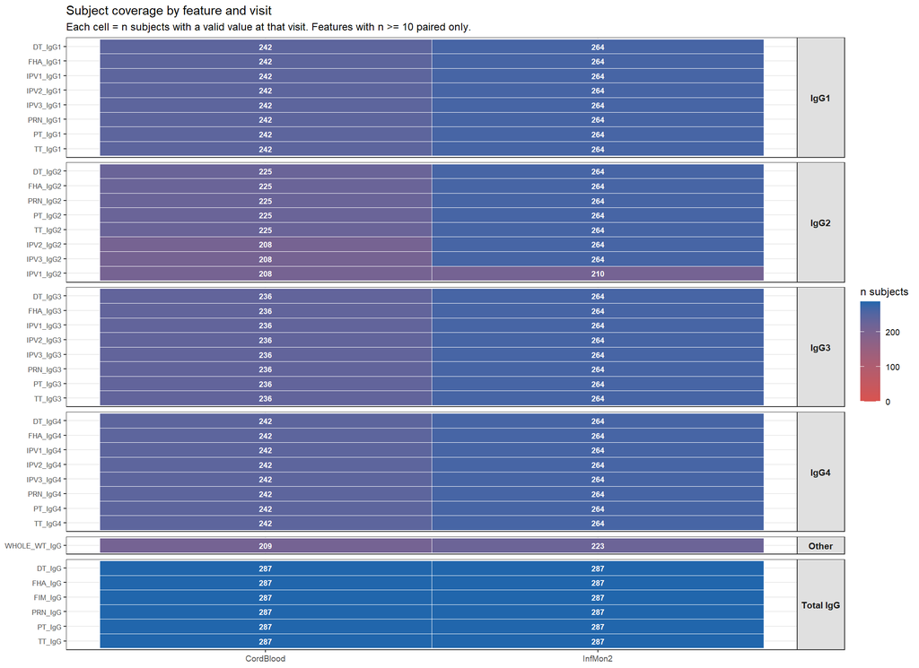

Figure M1. Coverage heatmap: number of subjects with a valid measurement at CordBlood and InfMon2 for every well-covered feature (n >= 10 paired). Features are grouped by analyte type and ordered by CordBlood n within group. The step-down in CordBlood coverage by analyte group (Type B missingness) and the consistent InfMon2 coverage are immediately visible.

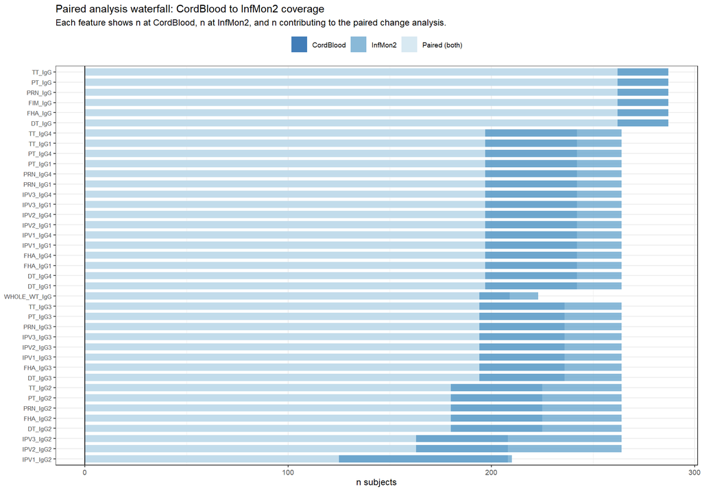

Figure M2. Paired analysis waterfall: for each well-covered feature, overlapping bars show n subjects at CordBlood (dark blue), n at InfMon2 (medium blue), and n paired at both (light blue). The gap between InfMon2 and paired bars is Type B+C+D missingness. Features ordered by n paired.

## Subject-level missingness patterns

The per-feature view above (Figures M1–M2) is computed from the coverage summary. To see missingness *at the subject level* we use the paired dataset directly: each subject contributes a known set of features to the paired change analysis, and the **number of features a subject contributes** reveals which assay batches they were part of. A subject who received the full panel contributes up to 10+ features; a subject in an early, total-IgG-only batch contributes far fewer.

One limitation to state plainly: the paired dataset contains only subjects who achieved **at least one** valid CordBlood↔︎InfMon2 pairing. Subjects who attended only one visit, or whose every measurement failed pairing, do not appear here at all — quantifying that group requires the per-visit raw records and is not attempted in this document. The per-feature coverage gaps in Table 1 (e.g. InfMon2 n exceeding CordBlood n) are the aggregate footprint of those subjects.

Table 3. Number of subjects contributing at least one paired feature to each analyte group. Derived from the paired dataset only. The drop from Total IgG down through the subclasses mirrors the CordBlood assay batch step-down in Table 2: fewer subjects had cord-blood subclass panels run, so fewer can contribute paired subclass features.

| Analyte group | N subjects contributing ≥ 1 paired feature |
| --- | --- |
| Total IgG | 262 |
| IgG1 | 197 |
| IgG4 | 197 |
| IgG3 | 194 |
| IgG2 | 180 |

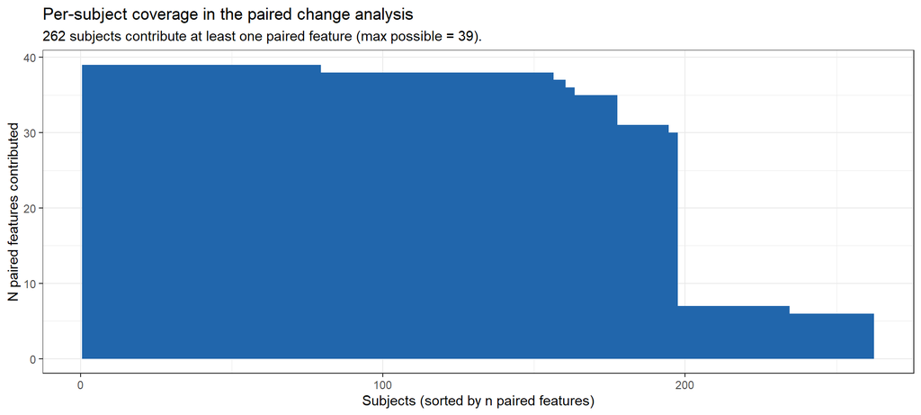

Figure M3. Per-subject paired-feature coverage. Each bar is one subject; height = number of distinct features that subject contributes to the paired change analysis, sorted descending. The flat plateaus reflect the assay batch structure: subjects either received a given subclass panel at CordBlood or did not, producing discrete coverage levels rather than a smooth gradient.

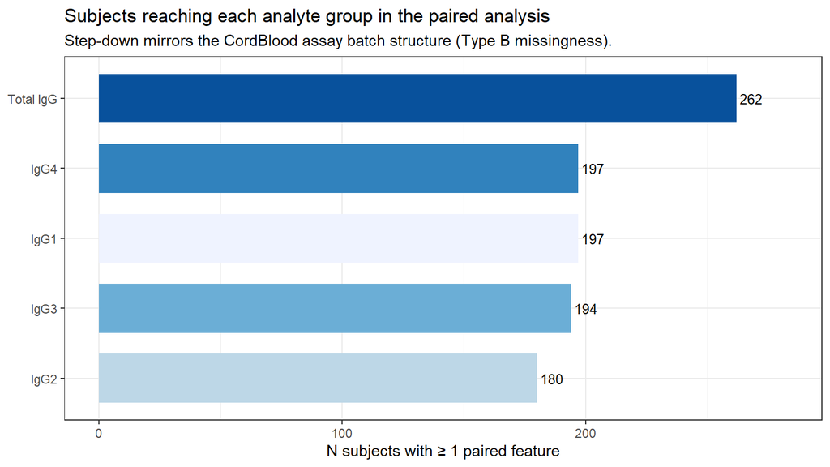

Figure M4. Number of subjects contributing at least one paired feature, by analyte group. The step-down from Total IgG through the IgG subclasses is the subject-level signature of the CordBlood assay batch rollout (Type B missingness): each successive subclass panel was run on fewer cord-blood samples, so progressively fewer subjects can contribute paired subclass features.

## Implications of the missingness structure for change estimates

**What the 25 “paired loss” subjects in total IgG mean.** For total IgG, both n<sub>cord</sub> and n<sub>inf</sub> are 287 — every subject had both visits and the feature was assayed — but only 262 contribute to the paired analysis. These 25 subjects have a valid visit record at both timepoints but a missing or QC-failed value at one. Because total IgG is the most basic assay readout, a QC failure here is more likely to reflect a sample-quality problem (haemolysed, insufficient volume, freeze-thaw issue) than a feature-specific assay failure. If these 25 subjects had systematically low or high starting titres, their exclusion could bias the estimated decay magnitude. **This group warrants direct inspection**: do they cluster by site, collection date, or maternal arm? Do their available values at one visit differ from the 262-subject group?

**What the InfMon2-only subjects mean.** Subjects with InfMon2 data but no CordBlood subclass data (the Type B gap: 264 − 197 = 67 for IgG1/4) are not drop-outs in any clinical sense — they simply joined the study after the cord subclass panel was added or were not in the batch that received it. They contribute fully to cross-sectional InfMon2 analyses but cannot contribute to any paired analysis. Their inclusion in InfMon2 models inflates the apparent InfMon2 sample size relative to what is available for change analyses.

- Across the **39** well-covered features, **12** are *mostly increasing*, **15** are *mostly decreasing*, and **12** are *mixed* (no clear net direction).
- Pooling all subject×feature observations, **40.6%** show an increase (median delta = **-0.088** log10).
- Of the **7** total-antigen IgG features (which, if passively transferred, must decay), **0** are *mostly increasing*.
- Per subject (mean delta across all their features), **22.1%** have a net positive shift (median per-subject offset = **-0.130** log10).
- Effector function and FcR-binding features (ADCD, ADCP, ADNP, FcgR2a, FcgR3b) and B-memory features have **zero CordBlood observations** and cannot contribute to this change analysis.

Table 4. Per-feature paired change CordBlood→InfMon2 (sorted by % increasing). Positive delta = increase = opposite of expected decay.

| feature | class | antigen | analyte | n_paired | % increase | % decrease | median delta | mean delta | p signed-rank | p sign-test | direction |
| --- | --- | --- | --- | --- | --- | --- | --- | --- | --- | --- | --- |
| PT_IgG3 | IgG subclass | PT | IgG3 | 194 | 87.6 | 12.4 | 0.263 | 0.254 | 0.00e+00 | 0.00e+00 | mostly increase |
| PT_IgG4 | IgG subclass | PT | IgG4 | 197 | 87.3 | 12.7 | 0.212 | 0.183 | 0.00e+00 | 0.00e+00 | mostly increase |
| DT_IgG4 | IgG subclass | DT | IgG4 | 197 | 86.3 | 13.7 | 0.517 | 0.445 | 0.00e+00 | 0.00e+00 | mostly increase |
| TT_IgG4 | IgG subclass | TT | IgG4 | 197 | 84.8 | 15.2 | 0.705 | 0.666 | 0.00e+00 | 0.00e+00 | mostly increase |
| DT_IgG3 | IgG subclass | DT | IgG3 | 194 | 83.0 | 17.0 | 0.144 | 0.156 | 0.00e+00 | 0.00e+00 | mostly increase |
| PRN_IgG4 | IgG subclass | PRN | IgG4 | 197 | 79.2 | 20.8 | 0.119 | 0.087 | 0.00e+00 | 0.00e+00 | mostly increase |
| IPV1_IgG2 | IgG subclass | IPV1 | IgG2 | 101 | 67.3 | 32.7 | 0.092 | 0.102 | 2.03e-05 | 6.41e-04 | mostly increase |
| TT_IgG2 | IgG subclass | TT | IgG2 | 180 | 67.2 | 32.8 | 0.152 | 0.153 | 1.40e-04 | 4.40e-06 | mostly increase |
| DT_IgG2 | IgG subclass | DT | IgG2 | 180 | 65.6 | 34.4 | 0.063 | -0.044 | 1.22e-01 | 3.62e-05 | mostly increase |
| IPV1_IgG3 | IgG subclass | IPV1 | IgG3 | 194 | 64.4 | 35.6 | 0.111 | 0.177 | 0.00e+00 | 7.06e-05 | mostly increase |
| IPV1_IgG4 | IgG subclass | IPV1 | IgG4 | 197 | 62.4 | 37.6 | 0.029 | 0.045 | 3.99e-03 | 5.91e-04 | mostly increase |
| IPV2_IgG3 | IgG subclass | IPV2 | IgG3 | 194 | 60.8 | 39.2 | 0.317 | 0.314 | 1.09e-05 | 3.14e-03 | mostly increase |
| PT_IgG2 | IgG subclass | PT | IgG2 | 180 | 58.9 | 41.1 | 0.031 | 0.009 | 1.08e-02 | 2.06e-02 | mixed |
| IPV3_IgG3 | IgG subclass | IPV3 | IgG3 | 194 | 58.8 | 41.2 | 0.168 | 0.317 | 2.10e-06 | 1.76e-02 | mixed |
| IPV2_IgG2 | IgG subclass | IPV2 | IgG2 | 163 | 55.8 | 44.2 | 0.012 | 0.028 | 6.08e-02 | 1.58e-01 | mixed |
| FHA_IgG2 | IgG subclass | FHA | IgG2 | 180 | 55.6 | 44.4 | 0.459 | -0.115 | 1.94e-01 | 1.57e-01 | mixed |
| IPV3_IgG2 | IgG subclass | IPV3 | IgG2 | 163 | 52.1 | 47.9 | 0.010 | -0.020 | 8.08e-01 | 6.39e-01 | mixed |
| IPV1_IgG1 | IgG subclass | IPV1 | IgG1 | 197 | 51.8 | 48.2 | 0.049 | 0.280 | 1.34e-04 | 6.69e-01 | mixed |
| IPV2_IgG4 | IgG subclass | IPV2 | IgG4 | 197 | 49.7 | 50.3 | 0.000 | -0.060 | 8.02e-01 | 1.00e+00 | mixed |
| TT_IgG3 | IgG subclass | TT | IgG3 | 194 | 49.0 | 51.0 | -0.001 | 0.019 | 3.80e-01 | 8.30e-01 | mixed |
| IPV3_IgG4 | IgG subclass | IPV3 | IgG4 | 197 | 46.2 | 53.8 | -0.004 | -0.010 | 4.89e-01 | 3.19e-01 | mixed |
| PRN_IgG3 | IgG subclass | PRN | IgG3 | 194 | 44.8 | 55.2 | -0.057 | -0.111 | 4.43e-04 | 1.72e-01 | mixed |
| FHA_IgG4 | IgG subclass | FHA | IgG4 | 197 | 41.1 | 58.9 | -0.166 | 0.203 | 6.34e-01 | 1.52e-02 | mixed |
| PRN_IgG2 | IgG subclass | PRN | IgG2 | 180 | 40.6 | 59.4 | -0.045 | -0.080 | 5.52e-03 | 1.37e-02 | mixed |
| FHA_IgG3 | IgG subclass | FHA | IgG3 | 194 | 38.7 | 61.3 | -0.084 | -0.066 | 3.51e-04 | 1.94e-03 | mostly decrease |
| IPV3_IgG1 | IgG subclass | IPV3 | IgG1 | 197 | 24.4 | 75.6 | -0.211 | -0.156 | 0.00e+00 | 0.00e+00 | mostly decrease |
| FHA_IgG1 | IgG subclass | FHA | IgG1 | 197 | 23.9 | 76.1 | -0.167 | -0.199 | 0.00e+00 | 0.00e+00 | mostly decrease |
| WHOLE_WT_IgG | Total IgG | WHOLE | WT_IgG | 194 | 23.2 | 76.8 | -0.260 | -0.368 | 0.00e+00 | 0.00e+00 | mostly decrease |
| TT_IgG1 | IgG subclass | TT | IgG1 | 197 | 22.3 | 77.7 | -0.154 | -0.168 | 0.00e+00 | 0.00e+00 | mostly decrease |
| PRN_IgG1 | IgG subclass | PRN | IgG1 | 197 | 15.2 | 84.8 | -0.262 | -0.249 | 0.00e+00 | 0.00e+00 | mostly decrease |
| IPV2_IgG1 | IgG subclass | IPV2 | IgG1 | 197 | 9.6 | 90.4 | -0.339 | -0.329 | 0.00e+00 | 0.00e+00 | mostly decrease |
| DT_IgG1 | IgG subclass | DT | IgG1 | 197 | 7.6 | 92.4 | -0.288 | -0.281 | 0.00e+00 | 0.00e+00 | mostly decrease |
| PT_IgG1 | IgG subclass | PT | IgG1 | 197 | 5.1 | 94.9 | -0.411 | -0.403 | 0.00e+00 | 0.00e+00 | mostly decrease |
| FHA_IgG | Total IgG | FHA | IgG | 262 | 3.1 | 96.9 | -0.581 | -0.548 | 0.00e+00 | 0.00e+00 | mostly decrease |
| FIM_IgG | Total IgG | FIM | IgG | 262 | 3.1 | 95.8 | -0.584 | -0.566 | 0.00e+00 | 0.00e+00 | mostly decrease |
| PRN_IgG | Total IgG | PRN | IgG | 262 | 3.1 | 96.9 | -0.600 | -0.571 | 0.00e+00 | 0.00e+00 | mostly decrease |
| PT_IgG | Total IgG | PT | IgG | 262 | 2.7 | 97.3 | -0.575 | -0.549 | 0.00e+00 | 0.00e+00 | mostly decrease |
| DT_IgG | Total IgG | DT | IgG | 262 | 2.3 | 97.7 | -0.601 | -0.566 | 0.00e+00 | 0.00e+00 | mostly decrease |
| TT_IgG | Total IgG | TT | IgG | 262 | 1.1 | 98.9 | -0.624 | -0.620 | 0.00e+00 | 0.00e+00 | mostly decrease |

Table 5. Per-analyte summary across all antigens. Each row pools all antigens for that analyte type. Ordered by median delta (most negative = strongest decay).

| Analyte | N features | N mostly increasing | N mostly decreasing | N mixed | Median delta (log10) | Mean % subjects increasing | Overall direction |
| --- | --- | --- | --- | --- | --- | --- | --- |
| IgG | 6 | 0 | 6 | 0 | -0.592 | 2.6 | predominantly decreasing |
| WT_IgG | 1 | 0 | 1 | 0 | -0.260 | 23.2 | predominantly decreasing |
| IgG1 | 8 | 0 | 7 | 1 | -0.236 | 20.0 | predominantly decreasing |
| IgG2 | 8 | 3 | 0 | 5 | 0.047 | 57.9 | mixed |
| IgG4 | 8 | 5 | 0 | 3 | 0.074 | 67.1 | predominantly increasing |
| IgG3 | 8 | 4 | 1 | 3 | 0.128 | 60.9 | mixed |

# Visualising Direction and Magnitude of Change

## Figure 1 — Feature-level lollipop

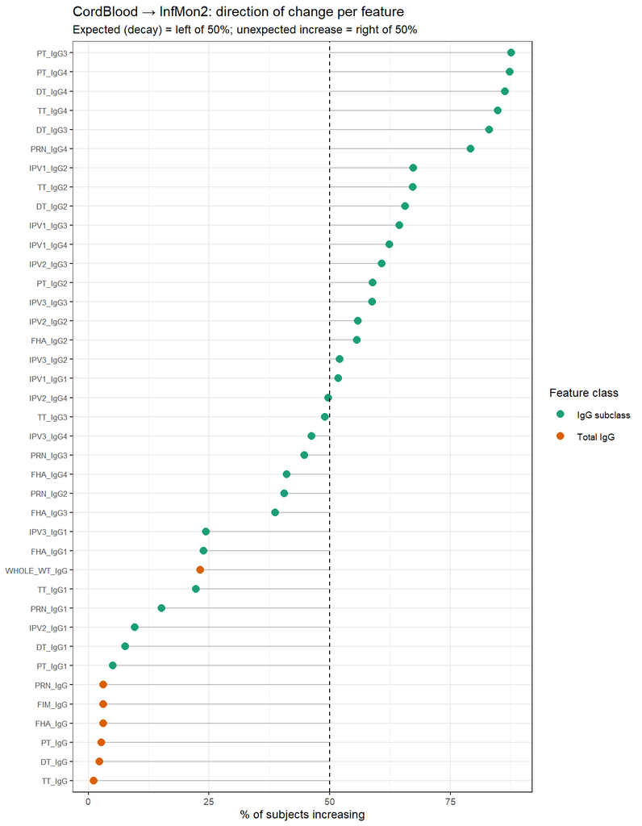

Figure 1. Percent of subjects increasing CordBlood→InfMon2, by feature, coloured by feature class. Dashed line = 50% (no net direction). Total IgG and IgG1 cluster at the low (decay) end; the IgG2/IgG3/IgG4 subclass features spread around the 50% line.

## Figure 2 — Delta distributions by feature class

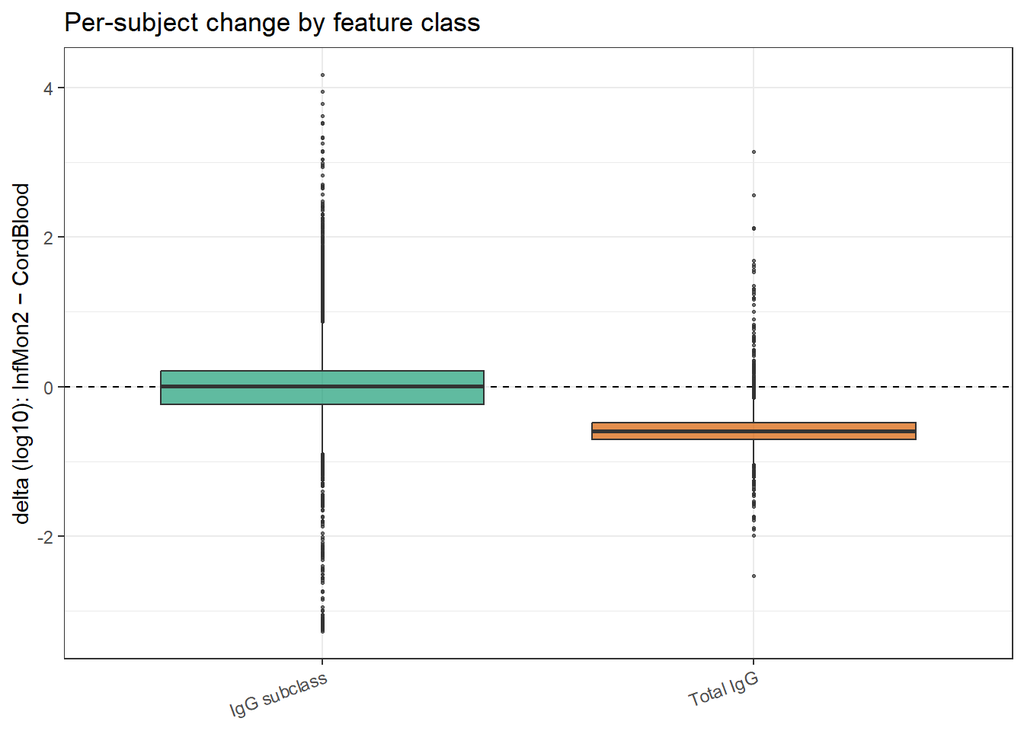

Figure 2. Distribution of per-subject delta (InfMon2 − CordBlood) by feature class. Zero = no change; expected decay sits below zero. Total IgG sits unambiguously below zero; IgG subclasses span both sides depending on subclass.

## Figure 3 — Per-subject average shift

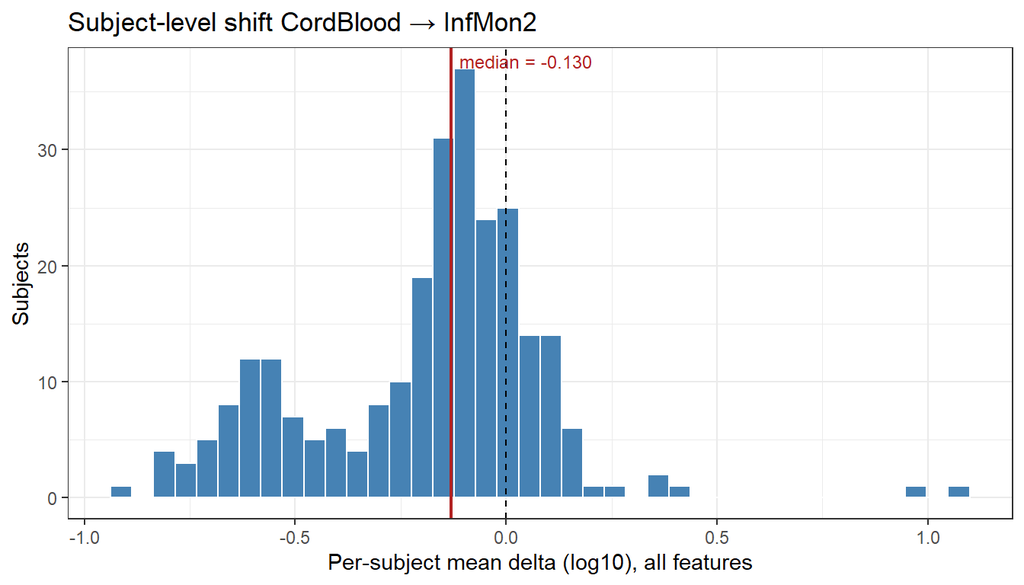

## Figure 4 — Per-antigen histograms (analytes pooled)

Each panel pools all analytes measured for that antigen. The dashed line marks zero; the red line marks the antigen-level median delta. Antigens are ordered from the most negative (strongest decay) to the most positive (strongest increase) median.

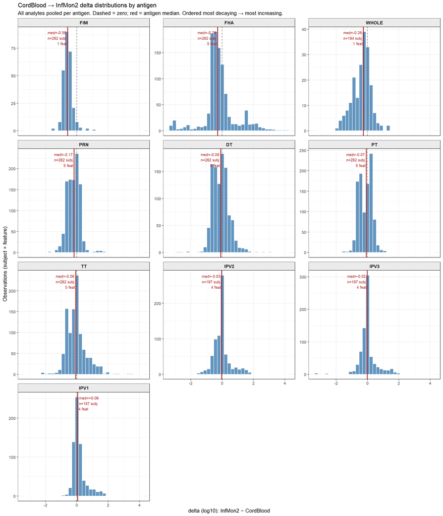

Figure 4. Per-subject delta distributions by antigen (all analytes pooled within each antigen). Dashed = zero; red = antigen median. Ordered by median delta.

Table 6. Per-antigen summary of CordBlood→InfMon2 change (ordered by median delta, most negative first). Each row pools all analytes available for that antigen.

| Antigen | N features | N mostly increasing | N mostly decreasing | N mixed | Median delta (log10) | Overall direction |
| --- | --- | --- | --- | --- | --- | --- |
| FIM | 1 | 0 | 1 | 0 | -0.584 | predominantly decreasing |
| WHOLE | 1 | 0 | 1 | 0 | -0.260 | predominantly decreasing |
| FHA | 5 | 0 | 3 | 2 | -0.166 | predominantly decreasing |
| PRN | 5 | 1 | 2 | 2 | -0.057 | mixed |
| TT | 5 | 2 | 2 | 1 | -0.001 | mixed |
| IPV3 | 4 | 0 | 1 | 3 | 0.003 | mixed |
| IPV2 | 4 | 1 | 1 | 2 | 0.006 | mixed |
| PT | 5 | 2 | 2 | 1 | 0.031 | mixed |
| DT | 5 | 3 | 2 | 0 | 0.063 | predominantly increasing |
| IPV1 | 4 | 3 | 0 | 1 | 0.071 | predominantly increasing |

# Per-Analyte Histograms: Figures 5a–5f

Each figure in this section fixes **one analyte** (IgG, IgG1, IgG2, IgG3, IgG4, or WHOLE_WT_IgG) and shows a separate histogram panel for each antigen measured with that analyte. This layout isolates whether a given IgG subclass behaves consistently across antigens, or whether the direction of change is antigen-specific. Features are ordered within each figure by their median delta (most decaying left/top, most increasing right/bottom).

**Note on effector functions and FcR binding:** CordBlood samples were not assayed for ADCD, ADCP, ADNP, FcgR2a, FcgR3b, or B-memory (Bmem) features — these have zero paired observations and cannot contribute to any CordBlood→InfMon2 change analysis. Any cord-to-infant change for these analytes remains unquantifiable from this dataset.

## Figure 5a — Total IgG (antigen-specific)

Total IgG is the reference measure of passively transferred maternal antibody. All six antigens measured at total-IgG level (DT, FHA, FIM, PRN, PT, TT) are expected to decay and, if the assay is working correctly, all should fall clearly below zero.

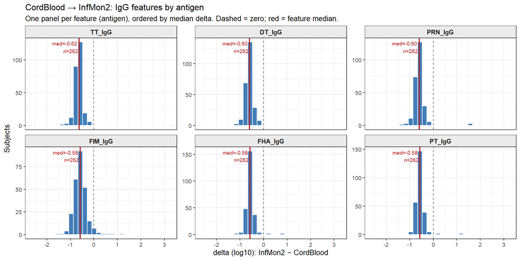

Figure 5a. Per-subject delta distributions for total antigen-specific IgG features (one panel per antigen, ordered by median delta). Total IgG decays for essentially all antigens — the expected catabolism of passively transferred maternal antibody, well-captured at the total-IgG level.

## Figure 5b — IgG1

IgG1 is the dominant IgG subclass in maternal serum and the primary isotype transferred across the placenta. If passive transfer drove the IgG1 pool at birth and no infant production has begun by 2 months, IgG1 should decay like total IgG.

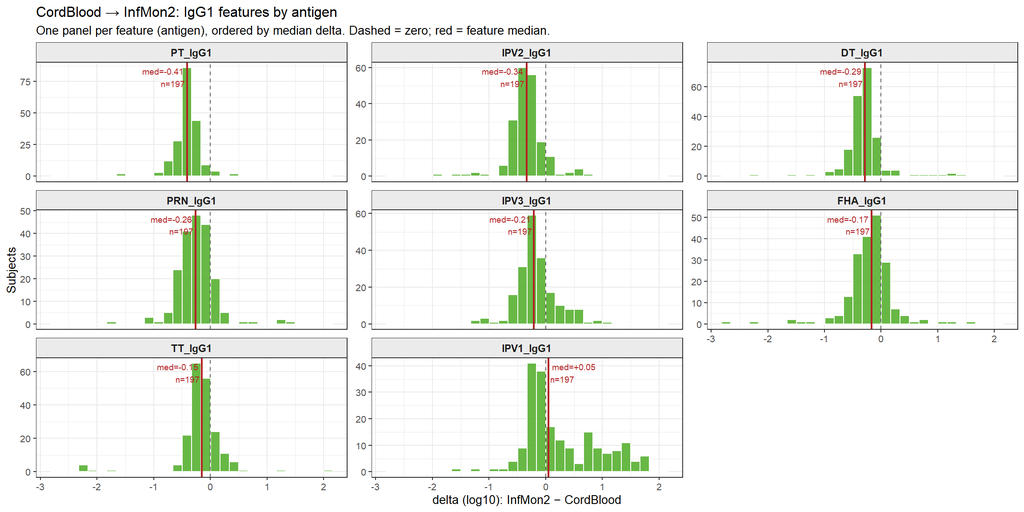

Figure 5b. Per-subject delta distributions for IgG1 features by antigen (ordered by median delta). IgG1 predominantly decreases, consistent with catabolic decay of passively transferred maternal IgG1; the magnitude of decay varies by antigen.

## Figure 5c — IgG2

IgG2 is the subclass most enriched in responses to polysaccharide antigens and is transferred across the placenta less efficiently than IgG1. Any systematic difference between cord-blood and peripheral-infant IgG2 quantification would stand out here.

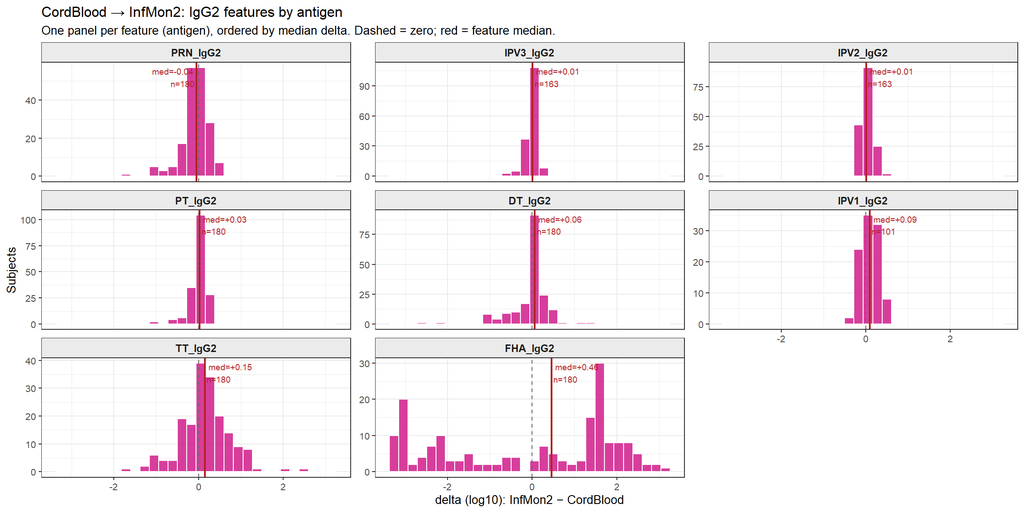

Figure 5c. Per-subject delta distributions for IgG2 features by antigen (ordered by median delta). IgG2 is small and mixed overall; any per-antigen positive residual should be read cautiously (floor or batch effect) rather than as antibody accrual.

## Figure 5d — IgG3

IgG3 has the shortest half-life of the IgG subclasses (~7 days vs ~21 days for IgG1) and is expected to decay fastest from cord levels. Rapid IgG3 catabolism would produce strongly negative deltas here; increases would be anomalous.

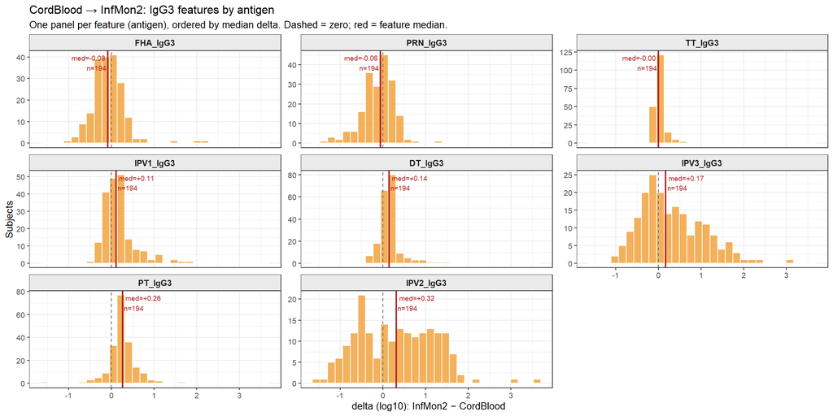

## Figure 5e — IgG4

IgG4 is typically the lowest-abundance IgG subclass in most individuals and is elevated in chronic antigen exposure (e.g. repeated vaccination). Placental transfer of IgG4 is less efficient than IgG1. Any measurement close to the assay floor in cord blood would appear to increase by 2 months as IgG4 rises with infant environmental exposure, even without maternal contribution.

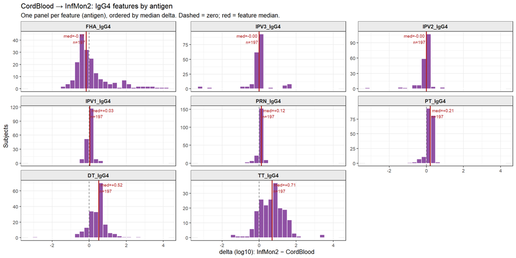

## Figure 5f — WHOLE_WT_IgG

WHOLE_WT_IgG is a single whole-cell lysate IgG measurement that integrates broadly across antigens. As a total-IgG-type measurement it should follow the same decay trajectory as the antigen-specific IgG features.

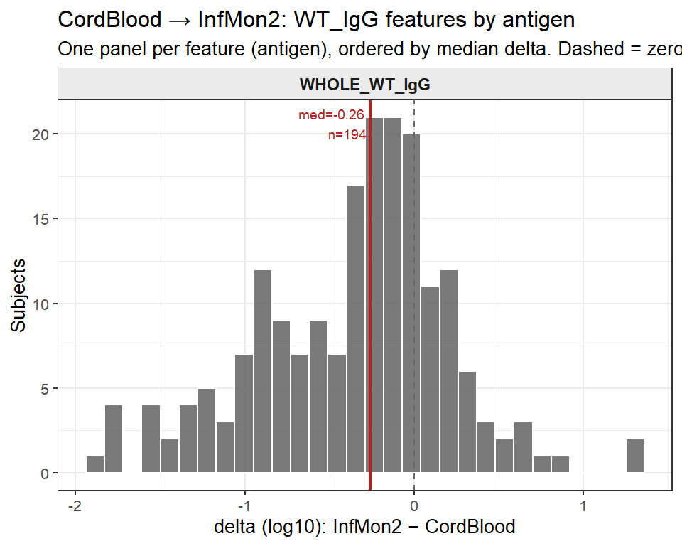

Figure 5f. Per-subject delta distribution for WHOLE_WT_IgG (a single feature). The whole-cell-lysate IgG decreases, consistent with decay of passively transferred whole-cell antibody.

# Stratified by maternal arm (TdaP vs TT)

The combined (pooled) decay results above are retained unchanged. This section ADDS the per-arm breakdown of the *same* CordBlood → InfMon2 change (Δ = InfMon2 − CordBlood, log10; negative = decay). Catabolism of passively transferred maternal IgG is a property of the antibody (subclass / FcRn recycling), not of the vaccine the mother received, so the decay rate is **expected to be similar across arms** even though the absolute starting (cord) levels differ. This section checks that directly.

## Direction summary by arm

Table 7. Decay-direction summary by maternal arm. Catabolic decay is antibody-Fc-driven and should appear similarly in both arms; a large arm-specific difference would instead point to biological (vaccine-driven) heterogeneity or a batch effect.

| arm_name | features | % feats mostly decreasing | median of feature median-deltas |
| --- | --- | --- | --- |
| TdaP | 39 | 43.6 | -0.010 |
| TT | 39 | 43.6 | 0.006 |

## Per-antigen decay by arm (total IgG and IgG1)

Table 8. Per-antigen decay for total IgG and IgG1, by maternal arm (six vaccine antigens, canonical order). Delta = InfMon2 - CordBlood (log10); negative = decay. Similar deltas across TdaP and TT indicate the decay rate does not depend on the vaccine, even where the cord starting level differs.

| Analyte | Antigen | Arm | n pairs | median CordBlood | median InfMon2 | median delta (inf-cord) | % decreasing | p signed-rank |
| --- | --- | --- | --- | --- | --- | --- | --- | --- |
| IgG | PT | Pooled | 262 | 1.629 | 1.077 | -0.575 | 97.3 | 0.00e+00 |
| IgG | PT | TdaP | 123 | 2.192 | 1.668 | -0.576 | 96.7 | 0.00e+00 |
| IgG | PT | TT | 139 | 0.974 | 0.457 | -0.573 | 97.8 | 0.00e+00 |
| IgG | FHA | Pooled | 262 | 1.823 | 1.304 | -0.581 | 96.9 | 0.00e+00 |
| IgG | FHA | TdaP | 123 | 2.568 | 2.024 | -0.568 | 95.9 | 0.00e+00 |
| IgG | FHA | TT | 139 | 1.276 | 0.713 | -0.590 | 97.8 | 0.00e+00 |
| IgG | PRN | Pooled | 262 | 1.221 | 0.663 | -0.600 | 96.9 | 0.00e+00 |
| IgG | PRN | TdaP | 123 | 2.303 | 1.807 | -0.597 | 96.7 | 0.00e+00 |
| IgG | PRN | TT | 139 | 0.690 | 0.028 | -0.614 | 97.1 | 0.00e+00 |
| IgG | FIM | Pooled | 262 | 0.979 | 0.397 | -0.584 | 95.8 | 0.00e+00 |
| IgG | FIM | TdaP | 123 | 1.032 | 0.481 | -0.573 | 95.9 | 0.00e+00 |
| IgG | FIM | TT | 139 | 0.885 | 0.277 | -0.586 | 95.7 | 0.00e+00 |
| IgG | TT | Pooled | 262 | 0.988 | 0.375 | -0.624 | 98.9 | 0.00e+00 |
| IgG | TT | TdaP | 123 | 0.988 | 0.361 | -0.617 | 98.4 | 0.00e+00 |
| IgG | TT | TT | 139 | 0.986 | 0.382 | -0.631 | 99.3 | 0.00e+00 |
| IgG | DT | Pooled | 262 | -0.371 | -0.974 | -0.601 | 97.7 | 0.00e+00 |
| IgG | DT | TdaP | 123 | -0.158 | -0.759 | -0.623 | 97.6 | 0.00e+00 |
| IgG | DT | TT | 139 | -0.869 | -1.425 | -0.596 | 97.8 | 0.00e+00 |
| IgG1 | PT | Pooled | 197 | 2.553 | 2.083 | -0.411 | 94.9 | 0.00e+00 |
| IgG1 | PT | TdaP | 92 | 3.090 | 2.761 | -0.392 | 93.5 | 0.00e+00 |
| IgG1 | PT | TT | 105 | 2.213 | 1.663 | -0.435 | 96.2 | 0.00e+00 |
| IgG1 | FHA | Pooled | 197 | 2.963 | 2.848 | -0.167 | 76.1 | 0.00e+00 |
| IgG1 | FHA | TdaP | 92 | 3.751 | 3.595 | -0.270 | 85.9 | 0.00e+00 |
| IgG1 | FHA | TT | 105 | 2.419 | 2.265 | -0.108 | 67.6 | 3.06e-05 |
| IgG1 | PRN | Pooled | 197 | 2.123 | 1.681 | -0.262 | 84.8 | 0.00e+00 |
| IgG1 | PRN | TdaP | 92 | 2.933 | 2.754 | -0.148 | 72.8 | 1.00e-07 |
| IgG1 | PRN | TT | 105 | 1.800 | 1.505 | -0.305 | 95.2 | 0.00e+00 |
| IgG1 | TT | Pooled | 197 | 3.545 | 3.422 | -0.154 | 77.7 | 0.00e+00 |
| IgG1 | TT | TdaP | 92 | 3.538 | 3.373 | -0.192 | 85.9 | 0.00e+00 |
| IgG1 | TT | TT | 105 | 3.557 | 3.457 | -0.116 | 70.5 | 9.24e-05 |
| IgG1 | DT | Pooled | 197 | 2.802 | 2.573 | -0.288 | 92.4 | 0.00e+00 |
| IgG1 | DT | TdaP | 92 | 3.091 | 2.881 | -0.307 | 93.5 | 0.00e+00 |
| IgG1 | DT | TT | 105 | 2.221 | 1.982 | -0.282 | 91.4 | 0.00e+00 |

Close agreement is the expected result: maternal IgG is catabolised at a rate set by the antibody (subclass / FcRn recycling), not by the vaccine, so both arms should decay in parallel. The vaccine sets the *starting* cord level (higher anti-pertussis in TdaP); it does not change the slope. A large arm difference would instead suggest a batch effect or genuine biological heterogeneity worth checking.

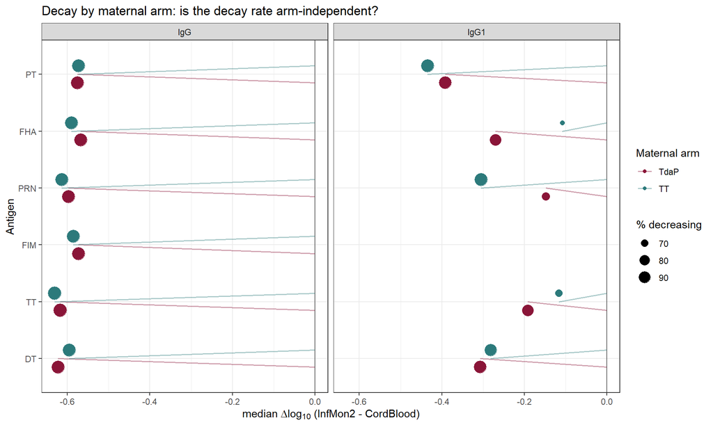

Figure A1. Decay (median delta log10, InfMon2 - CordBlood) for the six vaccine antigens, total IgG and IgG1, by maternal arm. Point size = percent of infants decreasing. Negative = decay. Overlapping TdaP/TT points indicate arm-independent catabolic decay.

# Maternal Antibody Half-Lives (Oguti et al. method)

The sections above summarise the CordBlood → InfMon2 change as a per-subject Δlog<sub>10</sub> and describe its **direction** (decay vs increase). This section re-expresses the same paired data as an **antibody half-life in days**, using the method of Oguti et al. (2022), *Vaccine* 40(3):450–458 (doi:10.1016/j.vaccine.2021.12.007), so that the decay observed here can be placed alongside their pooled, multi-country estimates for the same six diphtheria–tetanus–pertussis (DTP) antigens.

**Method (as published, adapted to a single study).** For each infant and antigen, Oguti et al. define the decay rate as the change in **log<sub>2</sub>** antibody titre between the two samples divided by the number of **days** between them; a one-unit fall on the log<sub>2</sub> scale is exactly one halving, which is why log<sub>2</sub> (not the natural log or log<sub>10</sub>) is the natural scale for half-lives. They then fit, **per antigen**, an intercept-only mixed model with a **study-specific random intercept**; the mean decay rate is the intercept, and the **half-life is the reciprocal of the absolute value of that mean rate** (with the confidence interval obtained by taking reciprocals of the rate CI limits). P-values are Bonferroni-adjusted across the six antigens, and infants whose titre *increased* over the interval (a rate ≥ 0, taken to indicate likely infection) are excluded.

Two adaptations are needed here. First, this document works on the **log<sub>10</sub>** scale, so each paired Δlog<sub>10</sub> is converted to Δlog<sub>2</sub> by multiplying by $1/\log_{10}(2) \approx 3.322$. Second, this is a **single study**, so the study-level random intercept of the meta-analysis has nothing to cluster; the model reduces to an **intercept-only linear model per antigen** (equivalently, the mean per-infant decay rate with a t-based 95% CI), which is exactly what the Oguti model collapses to when there is one study. Only the **total antigen-specific IgG** analyte is used, matching the transplacentally transferred IgG that Oguti et al. measured.

The per-infant sampling interval is the **exact number of days between the cord-blood draw and the 2-month (pre-primary) draw**, computed for each infant from the sample receipt dates in the study database (`INTERVAL_DAYS_BY_SUBJECT`; see `code/build_interval_days.R`). Because each infant’s decay rate is divided by that infant’s own interval, the half-lives are on a true per-day footing and require no assumed constant. The few infants whose 2-month receipt date is missing or unparseable fall back to the cohort-median interval so they still contribute to the antigen-specific means; this fallback affects only a handful of infants and does not change any between-group comparison.

## Interval used for the decay rate

Decay rates use the **exact per-infant cord -> 2-month interval from sample-receipt dates (n = 268 infants, median 60.0 d)**. Each infant’s rate is that infant’s Δlog<sub>2</sub> divided by that infant’s own cord-to-2-month interval in days, so the half-lives are on a true per-day footing and no assumed constant interval is needed. Of the infants contributing total-IgG decay data, **257** used an exact measured interval and **5** used the cohort-median fallback (2-month receipt date missing or unparseable).

## Half-lives in this study

Table H1. Half-life of transplacental total-IgG maternal antibody in this study, by antigen (Oguti et al. method: mean per-infant log2 decay rate per day; half-life = 1/|rate|). p-values test the null of no decay and are Bonferroni-adjusted across the six antigens.

| Antigen | N infants | Decay rate (log2/day) | Half-life (days) | 95% CI | p (decay != 0) | p Bonferroni |
| --- | --- | --- | --- | --- | --- | --- |
| Pertussis toxoid | 255 | -0.0336 | 29.8 | 28.6 - 31.1 | 0 | 0 |
| Pertactin | 254 | -0.0356 | 28.1 | 26.9 - 29.4 | 0 | 0 |
| FHA | 254 | -0.0334 | 29.9 | 28.8 - 31.2 | 0 | 0 |
| Fimbriae 2/3 | 251 | -0.0343 | 29.2 | 27.7 - 30.8 | 0 | 0 |
| Tetanus | 259 | -0.0361 | 27.7 | 26.7 - 28.8 | 0 | 0 |
| Diphtheria | 256 | -0.0345 | 29.0 | 27.9 - 30.2 | 0 | 0 |

Half-life point estimates in this study range from **27.7 (TT) to 29.9 (FHA)** days.

Table H2. Infants excluded from each antigen’s half-life because their titre increased over the interval (rate >= 0), following Oguti et al. (increases taken to indicate likely infection). A large excluded fraction for an antigen means the decay estimate rests on the decaying subset and should be read with that selection in mind.

| Antigen | N total | N excluded (increase) | N used (decay) | % excluded |
| --- | --- | --- | --- | --- |
| PT | 262 | 7 | 255 | 2.7 |
| PRN | 262 | 8 | 254 | 3.1 |
| FHA | 262 | 8 | 254 | 3.1 |
| FIM | 262 | 11 | 251 | 4.2 |
| TT | 262 | 3 | 259 | 1.1 |
| DT | 262 | 6 | 256 | 2.3 |

## Comparison with Oguti et al. (2022)

Table H3. This study (CordBlood -> 2-month total IgG) versus Oguti et al. 2022 (pooled individual-participant meta-analysis of the same six DTP antigens). ‘Diff’ is this study minus Oguti (positive = longer half-life here). ‘CIs overlap’ compares the two 95% intervals; ‘Within Oguti CI’ asks whether this study’s point estimate lies inside Oguti’s interval.

| Antigen | This study N | This study half-life (95% CI) | Oguti N | Oguti half-life (95% CI) | Diff (days) | CIs overlap | Within Oguti CI |
| --- | --- | --- | --- | --- | --- | --- | --- |
| Pertussis toxoid | 255 | 29.8 (28.6 - 31.1) | 549 | 30.0 (24.8 - 37.8) | -0.2 | yes | yes |
| Pertactin | 254 | 28.1 (26.9 - 29.4) | 1103 | 35.1 (30.7 - 41.1) | -7.0 | no | no |
| FHA | 254 | 29.9 (28.8 - 31.2) | 654 | 31.3 (28.3 - 35.1) | -1.4 | yes | yes |
| Fimbriae 2/3 | 251 | 29.2 (27.7 - 30.8) | 1022 | 33.5 (31.5 - 35.8) | -4.3 | no | no |
| Tetanus | 259 | 27.7 (26.7 - 28.8) | 1021 | 28.7 (24.4 - 35.0) | -1.0 | yes | yes |
| Diphtheria | 256 | 29.0 (27.9 - 30.2) | 620 | 33.1 (27.5 - 41.8) | -4.1 | yes | yes |

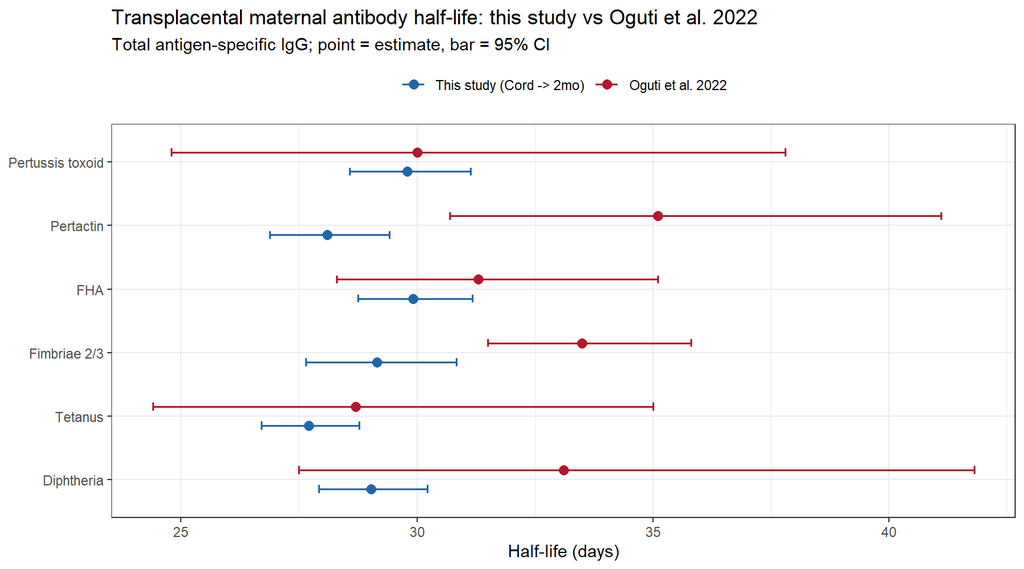

Figure H1. Half-life (days) of transplacental maternal total-IgG antibody by antigen: this study (CordBlood -> 2 months) versus Oguti et al. 2022. Points are half-life point estimates; horizontal bars are 95% CIs. Overlapping bars for an antigen indicate the two estimates are statistically compatible.

## Optional: half-lives by maternal arm

Table H4. Half-life by maternal arm. Oguti et al. found decay rates were largely unaffected by maternal vaccination (the vaccine sets the starting cord level, not the catabolic slope), so half-lives are expected to be similar across arms even where cord titres differ.

| Antigen | Arm | N infants | Half-life (days) | 95% CI |
| --- | --- | --- | --- | --- |
| Pertussis toxoid | TdaP | 119 | 29.6 | 28.1 - 31.4 |
| Pertussis toxoid | TT | 136 | 29.9 | 28.1 - 32.0 |
| Pertactin | TdaP | 119 | 28.4 | 26.7 - 30.3 |
| Pertactin | TT | 135 | 27.8 | 26.2 - 29.7 |
| FHA | TdaP | 118 | 29.7 | 28.0 - 31.6 |
| FHA | TT | 136 | 30.1 | 28.5 - 31.9 |
| Fimbriae 2/3 | TdaP | 118 | 28.6 | 26.3 - 31.4 |
| Fimbriae 2/3 | TT | 133 | 29.7 | 27.8 - 31.8 |
| Tetanus | TdaP | 121 | 27.5 | 26.0 - 29.1 |
| Tetanus | TT | 138 | 27.9 | 26.6 - 29.4 |
| Diphtheria | TdaP | 120 | 27.6 | 26.1 - 29.2 |
| Diphtheria | TT | 136 | 30.5 | 28.9 - 32.2 |

## Do maternal/infant factors modify the half-life? (Oguti et al. Figs 3–5)

Oguti et al. tested whether the decay rate is modified by infant **birthweight**, **gestational age at maternal vaccination**, and **maternal age**, and found no significant effect for any antigen. The clinical covariates needed to repeat that test are in `clin_assess` (`birth_weight`, `gestational_age_vaccination`, `maternal_age`), so the same analysis is run here on the total-IgG decay rate. Each infant’s rate uses that infant’s exact cord-to-2-month interval, so the covariate tests ask directly whether the per-infant decay rate depends on the covariate — exactly Oguti et al.’s question. They are reported from the continuous predictor (with the same PDF cut-points used only to present grouped half-lives), Bonferroni-adjusted across the six antigens.

Table H5. Bonferroni-adjusted p-values for modification of the total-IgG decay rate by each covariate (continuous predictor, one model per antigen), matching Oguti et al. Figs 3–5. Each infant’s rate uses that infant’s exact cord-to-2-month interval. As in the source paper, the expectation is that few or none reach significance.

| Antigen | Birthweight | Gestational age at vaccination | Maternal age |
| --- | --- | --- | --- |
| Pertussis toxoid | 1 | 1 | 1 |
| Pertactin | 1 | 1 | 1 |
| FHA | 1 | 1 | 1 |
| Fimbriae 2/3 | 1 | 1 | 1 |
| Tetanus | 1 | 1 | 1 |
| Diphtheria | 1 | 1 | 1 |

Of **18** covariate × antigen tests, **0** are significant after Bonferroni correction. This reproduces Oguti et al.: **no measured maternal or infant factor modifies the decay rate** of transplacental DTP antibody.

| Antigen | Group | N infants | Half-life (days) | 95% CI |
| --- | --- | --- | --- | --- |
| Pertussis toxoid | <3 kg | 101 | 29.1 | 26.9 - 31.6 |
| Pertussis toxoid | 3 - <3.5 kg | 84 | 29.6 | 28.0 - 31.5 |
| Pertussis toxoid | 3.5+ kg | 22 | 31.4 | 26.3 - 39.0 |
| Pertactin | <3 kg | 101 | 27.4 | 25.5 - 29.5 |
| Pertactin | 3 - <3.5 kg | 83 | 27.8 | 26.1 - 29.8 |
| Pertactin | 3.5+ kg | 22 | 27.9 | 22.8 - 35.9 |
| FHA | <3 kg | 102 | 29.5 | 27.6 - 31.6 |
| FHA | 3 - <3.5 kg | 83 | 30.4 | 28.3 - 32.8 |
| FHA | 3.5+ kg | 22 | 30.3 | 25.9 - 36.5 |
| Fimbriae 2/3 | <3 kg | 103 | 28.7 | 26.7 - 31.2 |
| Fimbriae 2/3 | 3 - <3.5 kg | 81 | 29.0 | 26.5 - 32.0 |
| Fimbriae 2/3 | 3.5+ kg | 21 | 27.4 | 23.9 - 32.1 |
| Tetanus | <3 kg | 104 | 28.1 | 26.5 - 29.8 |
| Tetanus | 3 - <3.5 kg | 85 | 26.9 | 25.4 - 28.6 |
| Tetanus | 3.5+ kg | 22 | 28.4 | 23.5 - 35.9 |
| Diphtheria | <3 kg | 103 | 28.9 | 27.4 - 30.6 |
| Diphtheria | 3 - <3.5 kg | 84 | 28.4 | 26.7 - 30.3 |
| Diphtheria | 3.5+ kg | 22 | 30.5 | 24.8 - 39.6 |

| Antigen | Group | N infants | Half-life (days) | 95% CI |
| --- | --- | --- | --- | --- |
| Pertussis toxoid | 27 - <32 wk | 175 | 29.9 | 28.4 - 31.5 |
| Pertussis toxoid | 32+ wk | 35 | 28.1 | 24.8 - 32.3 |
| Pertactin | 27 - <32 wk | 173 | 28.0 | 26.7 - 29.5 |
| Pertactin | 32+ wk | 36 | 26.2 | 22.9 - 30.7 |
| FHA | 27 - <32 wk | 174 | 30.2 | 28.8 - 31.8 |
| FHA | 32+ wk | 36 | 28.4 | 25.4 - 32.3 |
| Fimbriae 2/3 | 27 - <32 wk | 172 | 29.3 | 27.6 - 31.2 |
| Fimbriae 2/3 | 32+ wk | 36 | 26.4 | 23.8 - 29.6 |
| Tetanus | 27 - <32 wk | 178 | 27.6 | 26.5 - 28.8 |
| Tetanus | 32+ wk | 36 | 27.8 | 24.2 - 32.5 |
| Diphtheria | 27 - <32 wk | 176 | 29.1 | 27.8 - 30.5 |
| Diphtheria | 32+ wk | 36 | 28.0 | 25.1 - 31.6 |

| Antigen | Group | N infants | Half-life (days) | 95% CI |
| --- | --- | --- | --- | --- |
| Pertussis toxoid | <25 yr | 75 | 29.1 | 27.3 - 31.1 |
| Pertussis toxoid | 25 - <30 yr | 81 | 30.8 | 28.8 - 32.9 |
| Pertussis toxoid | 30+ yr | 54 | 28.5 | 25.1 - 32.9 |
| Pertactin | <25 yr | 74 | 26.7 | 24.8 - 29.0 |
| Pertactin | 25 - <30 yr | 80 | 28.5 | 26.6 - 30.7 |
| Pertactin | 30+ yr | 55 | 27.8 | 24.9 - 31.5 |
| FHA | <25 yr | 74 | 29.5 | 27.6 - 31.6 |
| FHA | 25 - <30 yr | 81 | 30.2 | 28.5 - 32.2 |
| FHA | 30+ yr | 55 | 30.0 | 26.7 - 34.4 |
| Fimbriae 2/3 | <25 yr | 74 | 28.3 | 26.2 - 30.7 |
| Fimbriae 2/3 | 25 - <30 yr | 81 | 29.5 | 27.0 - 32.5 |
| Fimbriae 2/3 | 30+ yr | 53 | 28.4 | 25.3 - 32.4 |
| Tetanus | <25 yr | 75 | 26.5 | 24.7 - 28.6 |
| Tetanus | 25 - <30 yr | 83 | 28.1 | 26.3 - 30.2 |
| Tetanus | 30+ yr | 56 | 28.5 | 26.5 - 30.7 |
| Diphtheria | <25 yr | 75 | 27.4 | 25.6 - 29.6 |
| Diphtheria | 25 - <30 yr | 82 | 30.7 | 28.8 - 32.9 |
| Diphtheria | 30+ yr | 55 | 28.5 | 26.2 - 31.1 |

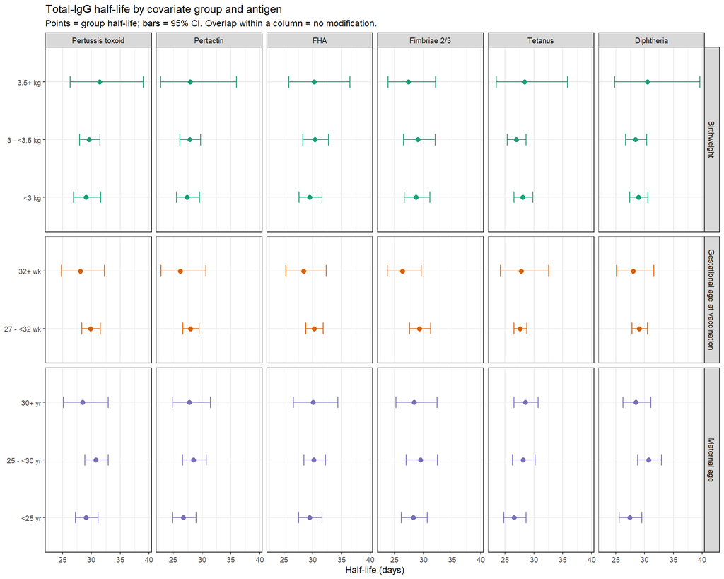

Figure H2. Total-IgG half-life by covariate group and antigen (this study). Points are group half-lives; bars are 95% CIs. Overlapping bars within an antigen indicate the covariate does not modify decay — the pattern Oguti et al. reported for birthweight, gestational age at vaccination, and maternal age.

## What the comparison shows

Across the **6** antigens with a published counterpart, this study’s half-life point estimate falls **inside** the Oguti et al. 95% CI for **4**, and the two 95% CIs **overlap** for **4**. The mean absolute difference between the two point estimates is **3.0 days**. Where an antigen does **not** overlap, the most likely explanations are (i) assay/scale differences between this cohort and the pooled studies, or (ii) genuine cohort-specific decay; the sampling interval is now measured per infant and so is not a source of divergence. The per-antigen rows in Table H3 identify which antigens diverge and by how much.

As in Oguti et al., the half-lives are similar across antigens — the biological message is that maternal DTP antibody decays at broadly the same rate regardless of antigen, so the *starting* cord titre (set by maternal vaccination and placental transfer) is what determines how long each infant stays above a protective threshold before its own primary immunisation.

# Interpretation

*All quantities in this section are computed from the current data at knit time (from `feat_summary`, `analyte_sum`, `decay_all` and the headline diagnostics). Nothing is hardcoded, so the narrative always matches the tables and figures above.*

This comparison measures **decay of passively transferred maternal antibody** between birth (`CordBlood`) and the 2-month visit (`InfMon2`), with Δ = InfMon2 − CordBlood (log10). Because this window precedes the infant’s primary immunisation, the infant is not yet producing its own antigen-specific antibody, so the expected signal is **decay (Δ < 0)** for genuinely transferred antibody. A positive Δ for a subclass is therefore a flag for a floor or batch effect rather than true antibody accrual.

## Overview

Across the **39** well-covered features, **15** are mostly decreasing, **12** mostly increasing, and **12** mixed. The pooled median Δ is **-0.088** log10 and **77.9%** of infants have a net negative mean shift. Decay should dominate the features that reflect genuinely transferred antibody (total IgG and IgG1); where a subclass shows a positive residual it is flagged below for cautious reading.

By analyte, the **decaying** compartments are IgG, WT_IgG, IgG1; **mixed**, IgG2, IgG3; any **net-positive**, IgG4. Total IgG is measured on a separate ELISA path and IgG1 on the bead array; agreement between the two anchors the decay signal as real rather than a scaling artefact.

## What the data show, by analyte

- **Total IgG** — strongest decay: TT (-0.62, 99% down); DT (-0.60, 98% down); PRN (-0.60, 97% down); FIM (-0.58, 96% down).
- **IgG1** — strongest decay: PT (-0.41, 95% down); IPV2 (-0.34, 90% down); DT (-0.29, 92% down); PRN (-0.26, 85% down).
- **IgG2** — largest residual positive (read cautiously): FHA (+0.46, 56% up); TT (+0.15, 67% up); IPV1 (+0.09, 67% up); DT (+0.06, 66% up).
- **IgG3** — largest residual positive (read cautiously): IPV2 (+0.32, 61% up); PT (+0.26, 88% up); IPV3 (+0.17, 59% up); DT (+0.14, 83% up).
- **IgG4** — largest residual positive (read cautiously): TT (+0.70, 85% up); DT (+0.52, 86% up); PT (+0.21, 87% up); PRN (+0.12, 79% up).

Total IgG and IgG1 decay is the catabolism of passively transferred maternal antibody. Positive residuals in IgG2/IgG3/IgG4 are most consistent with floor effects (these subclasses sit very low in cord blood, so on the log10 scale a small absolute value reads as a positive delta) or residual batch structure — not infant antibody production, which does not occur before the 2-month primary immunisation. They are antigen-specific rather than a uniform subclass shift, so they should be read per antigen and treated cautiously.

## Focus: *Bordetella pertussis* antigens

Decay of the pertussis antigens present in the data (the antibody maternal vaccination delivered to the infant):

- **PT** — total IgG -0.57 (97% down); IgG1 -0.41 (95% down)
- **FHA** — total IgG -0.58 (97% down); IgG1 -0.17 (76% down)
- **PRN** — total IgG -0.60 (97% down); IgG1 -0.26 (85% down)
- **FIM** — total IgG -0.58 (96% down)

The decay rate of anti-pertussis total IgG/IgG1 sets how quickly the infant’s maternally derived protection wanes before its own vaccination: the `CordBlood` level (driven by maternal vaccination and placental transfer) sets the starting point, and this decay sets the slope toward the window of susceptibility.

## Reliability of each estimand

Total IgG and IgG1 decay are the most reliable estimands from the CordBlood → InfMon2 comparison: total IgG comes from the RIVM ELISA path and does not pass through the bead-array cross-plate normalisation, IgG1 is the dominant transferred subclass, and the two agree. The normalised IgG2/IgG3/IgG4 deltas are usable but small; any per-antigen positive residual should be treated as antigen-specific (a floor or batch signature) rather than as a uniform subclass trend or as infant antibody production. Effector-function, FcR-binding, and B-memory readouts (ADCD, ADCP, ADNP, FcgR2a, FcgR3b, Bmem) were not assayed in CordBlood, so their birth-to-2-month trajectory is unobserved in this dataset.

## What would confirm or refine this interpretation

- **Examine absolute cord-blood distributions for any antigen with a residual subclass increase** — if a large fraction of infants sit near the assay floor, the floor-effect explanation is confirmed.
- **Check whether residual subclass increases correlate with cord-blood level** (regression to the mean): the lowest cord values showing the largest positive deltas points to a floor effect.
- **Read Tables 7–8 and Figure A1** to confirm decay is parallel across arms rather than relying on the pooled medians alone.
- **Correlate per-subject mean delta with plate/batch metadata** (Figure 3): residual plate-level clustering would indicate an incomplete cross-plate correction for some plates.

# Participant Accounting

Table 9. Per-feature paired availability (n CordBlood / n InfMon2 / n used).

| Section | Stratum | Model | N entered | N used | N dropped | Dropped due to (NA driver) |
| --- | --- | --- | --- | --- | --- | --- |
| Coverage | DT_IgG | paired availability | 287 | 262 | 25 | CordBlood n=287, InfMon2 n=287 |
| Coverage | FHA_IgG | paired availability | 287 | 262 | 25 | CordBlood n=287, InfMon2 n=287 |
| Coverage | FIM_IgG | paired availability | 287 | 262 | 25 | CordBlood n=287, InfMon2 n=287 |
| Coverage | PRN_IgG | paired availability | 287 | 262 | 25 | CordBlood n=287, InfMon2 n=287 |
| Coverage | PT_IgG | paired availability | 287 | 262 | 25 | CordBlood n=287, InfMon2 n=287 |
| Coverage | TT_IgG | paired availability | 287 | 262 | 25 | CordBlood n=287, InfMon2 n=287 |
| Coverage | DT_IgG1 | paired availability | 264 | 197 | 67 | CordBlood n=242, InfMon2 n=264 |
| Coverage | DT_IgG4 | paired availability | 264 | 197 | 67 | CordBlood n=242, InfMon2 n=264 |
| Coverage | FHA_IgG1 | paired availability | 264 | 197 | 67 | CordBlood n=242, InfMon2 n=264 |
| Coverage | FHA_IgG4 | paired availability | 264 | 197 | 67 | CordBlood n=242, InfMon2 n=264 |
| Coverage | IPV1_IgG1 | paired availability | 264 | 197 | 67 | CordBlood n=242, InfMon2 n=264 |
| Coverage | IPV1_IgG4 | paired availability | 264 | 197 | 67 | CordBlood n=242, InfMon2 n=264 |
| Coverage | IPV2_IgG1 | paired availability | 264 | 197 | 67 | CordBlood n=242, InfMon2 n=264 |
| Coverage | IPV2_IgG4 | paired availability | 264 | 197 | 67 | CordBlood n=242, InfMon2 n=264 |
| Coverage | IPV3_IgG1 | paired availability | 264 | 197 | 67 | CordBlood n=242, InfMon2 n=264 |
| Coverage | IPV3_IgG4 | paired availability | 264 | 197 | 67 | CordBlood n=242, InfMon2 n=264 |
| Coverage | PRN_IgG1 | paired availability | 264 | 197 | 67 | CordBlood n=242, InfMon2 n=264 |
| Coverage | PRN_IgG4 | paired availability | 264 | 197 | 67 | CordBlood n=242, InfMon2 n=264 |
| Coverage | PT_IgG1 | paired availability | 264 | 197 | 67 | CordBlood n=242, InfMon2 n=264 |
| Coverage | PT_IgG4 | paired availability | 264 | 197 | 67 | CordBlood n=242, InfMon2 n=264 |
| Coverage | TT_IgG1 | paired availability | 264 | 197 | 67 | CordBlood n=242, InfMon2 n=264 |
| Coverage | TT_IgG4 | paired availability | 264 | 197 | 67 | CordBlood n=242, InfMon2 n=264 |
| Coverage | DT_IgG3 | paired availability | 264 | 194 | 70 | CordBlood n=236, InfMon2 n=264 |
| Coverage | FHA_IgG3 | paired availability | 264 | 194 | 70 | CordBlood n=236, InfMon2 n=264 |
| Coverage | IPV1_IgG3 | paired availability | 264 | 194 | 70 | CordBlood n=236, InfMon2 n=264 |
| Coverage | IPV2_IgG3 | paired availability | 264 | 194 | 70 | CordBlood n=236, InfMon2 n=264 |
| Coverage | IPV3_IgG3 | paired availability | 264 | 194 | 70 | CordBlood n=236, InfMon2 n=264 |
| Coverage | PRN_IgG3 | paired availability | 264 | 194 | 70 | CordBlood n=236, InfMon2 n=264 |
| Coverage | PT_IgG3 | paired availability | 264 | 194 | 70 | CordBlood n=236, InfMon2 n=264 |
| Coverage | TT_IgG3 | paired availability | 264 | 194 | 70 | CordBlood n=236, InfMon2 n=264 |

[output cut: 56 more lines]

*Reuses the shared pipeline (`config/endpoints.R`, `R/serology_helpers.R`, the global visit recode, and the N-tracker). Knit both formats with* `rmarkdown::render("cord_to_infmon2_analysis_refactored.Rmd", output_format = "all")`.